# Analysing DemoS runs using VedaR

30/11/2021

## Importing the data

- R is efficient at handling data in “long” format: each column is a variable and repeated measures are in separate rows (Excel tables are often use “wide” format)
- The `prep_data()` function imports and combines the data contained in the vd, vds, and vde file. This generates a single long R dataframe (tibble). All strings are in lower case, missing data is replaced with NA (or “annual” for timeslice).
- Here, we import all the data from demos_001 to create a dataframe object `demos_001`, and display the data in an interactive table `demos_001`

|  | attribute | commodity | process | period | region | vintage | timeslice | userconstraint | pv | commodity_description | process_description | userconstraint_description | commodity_set | process_set | userconstraint_set |
| --- | --- | --- | --- | --- | --- | --- | --- | --- | --- | --- | --- | --- | --- | --- | --- |
| 1 | var_act |  | dtpscoa | 2005 | reg1 | 2005 | annual |  | 13413.96 |  | demand technology total primary supply - coa |  |  | dmd |  |
| 2 | var_act |  | expcoa1 | 2005 | reg1 | 2005 | annual |  | 1147.069 |  | export of solid fuels step 1 |  |  | ire |  |
| 3 | var_act |  | impcoa1 | 2005 | reg1 | 2005 | annual |  | 6462.671 |  | import of solid fuels step 1 |  |  | ire |  |
| 4 | var_act |  | mincoa1 | 2005 | reg1 | 2005 | annual |  | 6073.7685 |  | domestic supply of solid fuels step 1 |  |  | ire |  |
| 5 | var_act |  | mincoa2 | 2005 | reg1 | 2005 | annual |  | 2024.5895 |  | domestic supply of solid fuels step 2 |  |  | ire |  |
| 6 | var_act |  | dtpscoa | 2006 | reg1 | 2006 | annual |  | 13413.96 |  | demand technology total primary supply - coa |  |  | dmd |  |
| 7 | var_act |  | expcoa1 | 2006 | reg1 | 2006 | annual |  | 1147.069 |  | export of solid fuels step 1 |  |  | ire |  |
| 8 | var_act |  | impcoa1 | 2006 | reg1 | 2006 | annual |  | 6462.671 |  | import of solid fuels step 1 |  |  | ire |  |
| 9 | var_act |  | mincoa1 | 2006 | reg1 | 2006 | annual |  | 6073.7685 |  | domestic supply of solid fuels step 1 |  |  | ire |  |
| 10 | var_act |  | mincoa2 | 2006 | reg1 | 2006 | annual |  | 2024.5895 |  | domestic supply of solid fuels step 2 |  |  | ire |  |

[output cut: 64 more lines]

## Comparing the data to veda tables

- We can compare results produced by VedaR to those produced from tables generated by the Veda graphical-user interface.
- Here, we compare the output of the “All costs” Veda table to comparable output from VedaR.

Veda csv output

Attribute

Commodity

Process

Period

Region

Pv

Cost_Flo [Annual flow costs (including import/export prices)]

COA

EXPCOA1

2005

REG1

-3154.440

Cost_Flo [Annual flow costs (including import/export prices)]

COA

EXPCOA1

2006

REG1

-3154.440

Cost_Flo [Annual flow costs (including import/export prices)]

COA

IMPCOA1

2005

REG1

17772.345

Cost_Flo [Annual flow costs (including import/export prices)]

COA

IMPCOA1

2006

REG1

17772.345

Cost_Flo [Annual flow costs (including import/export prices)]

COA

MINCOA1

2005

REG1

12147.537

Cost_Flo [Annual flow costs (including import/export prices)]

COA

MINCOA1

2006

REG1

12147.537

Cost_Flo [Annual flow costs (including import/export prices)]

COA

MINCOA2

2005

REG1

5061.474

Cost_Flo [Annual flow costs (including import/export prices)]

COA

MINCOA2

2006

REG1

5061.474

Cost_Fom [Annual fixed operating and maintenance costs]

DTPSCOA

2005

REG1

2823.992

Cost_Fom [Annual fixed operating and maintenance costs]

DTPSCOA

2006

REG1

2823.992

Cost_Inv [Annual investment costs]

DTPSCOA

2005

REG1

11057.162

Cost_Inv [Annual investment costs]

DTPSCOA

2006

REG1

11057.162

Cost_Salv [Salvage values of capacities at EOH+1]

DTPSCOA

REG1

113069.549

VedaR data

| attribute | commodity | process | period | region | pv |
| --- | --- | --- | --- | --- | --- |
| cost_flo | coa | expcoa1 | 2005 | reg1 | -3154.440 |
| cost_flo | coa | expcoa1 | 2006 | reg1 | -3154.440 |
| cost_flo | coa | impcoa1 | 2005 | reg1 | 17772.345 |
| cost_flo | coa | impcoa1 | 2006 | reg1 | 17772.345 |
| cost_flo | coa | mincoa1 | 2005 | reg1 | 12147.537 |
| cost_flo | coa | mincoa1 | 2006 | reg1 | 12147.537 |
| cost_flo | coa | mincoa2 | 2005 | reg1 | 5061.474 |
| cost_flo | coa | mincoa2 | 2006 | reg1 | 5061.474 |
| cost_fom | NA | dtpscoa | 2005 | reg1 | 2823.992 |
| cost_fom | NA | dtpscoa | 2006 | reg1 | 2823.992 |
| cost_inv | NA | dtpscoa | 2005 | reg1 | 11057.162 |
| cost_inv | NA | dtpscoa | 2006 | reg1 | 11057.162 |
| cost_salv | NA | dtpscoa | NA | reg1 | 113069.549 |

## Visually presenting data with R

- A powerful and widely-used data visualisation package in R is ggplot
- Here, we create a plot to display compare costs over years broken down by process, from the demos_001 data

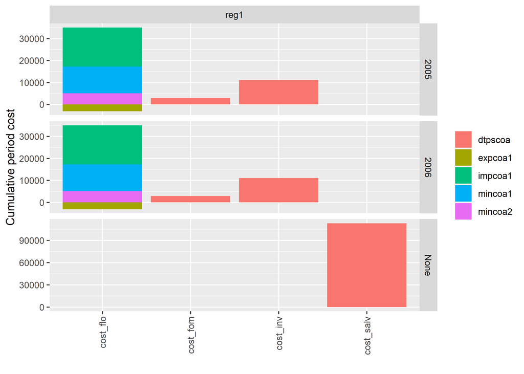

- We can create a plot for a different dataset by simply changing the data that is passed to the plot.
- Here, we plot the demos_007 data by changing the object data_to_plot. All other lines remaing the same

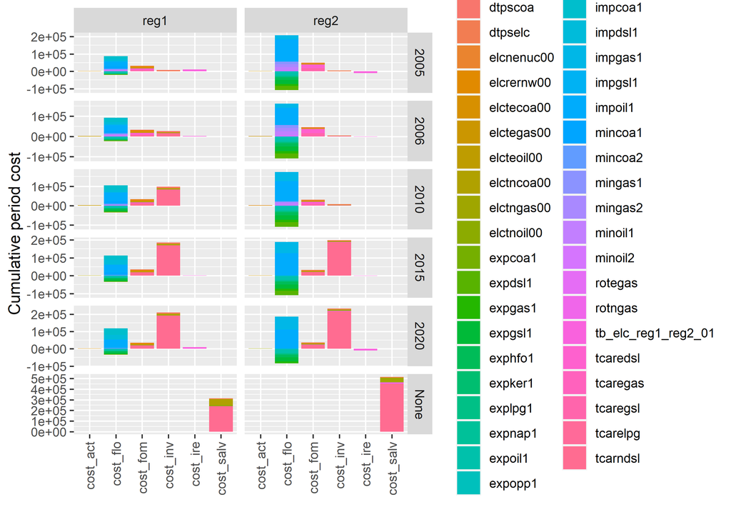